# DTC Q3

Erik Campbell, Kristen Higashi

8/22/2022

# 1 Purpose Statement

The purpose of this document is to investigate the effect of COVID on working individuals across industries and regions. Retail needs to worry about who has money to spend. In order to have money, you need to make money. Thus our focus is to determine who is working, what they are doing, and how that activity has changed across time.

# 2 Dataset Overview

Our analysis applies 3 main data sources:

| Variable | Definition |
| --- | --- |
| `YEAR` | Year survey was taken |
| `MONTH` | Month survey was taken |
| `EMPSTAT` | Employment status |
| `WTFINL` | Survey person weight (as calculated by CPS) |
| `IND` | Respondent’s work industry code |
| `REGION` | Respondents location (regional) |
| `AGE` | Respondent’s age |
| `SEX` | Marker for respondent sex assigned at birth |
| `RACE` | Marker for respondent’s race |

2. Provided industry csv (*indnames.csv*) Converts IPUMS industry codes to industry names

| Variable | Definition |
| --- | --- |
| `IND` | Work industry code (joins to IPUMS IND field) |
| `indname` | Work industry English name |

3. Provided geographic csv (*state-geocodes-v2021.csv*) Converts IPUMS geographies (STATEFIP) to readable geo names.

| Variable | Definition |
| --- | --- |
| `STATEFIP` | State FIP code (joins to IPUMS STATEFIP field) |
| `State` | State English name |

# 3 Assumptions & Conclusion

We assumed that the number of jobs in an industry and money a family has to spend on items are equivalent within all industry categories. This is not necessarily true as not all jobs are created equal in terms of amount of discretionary money a family has to spend on goods and services. We’ve not taken into account household savings and debt rates from Jan 2019 through Dec 2021, and these factors play a role in discretionary income families have to spend. In the future, we’d take into account and create faminly income on the monthly level and not just industry members of household worked in, but account for their job. In retrospect, accounting for jobs within industries that can be performed from an employee’s home would assist in identifying and quantifying how many earners moved from cities to suburbs or rural areas. Cohort that relocated during the pandemic to suburbs, working in high-earninging occupations, present an opportunity for businesses to meet customers demands at different geographic locations.

The below is in relation to the unemployment rate in Agriculture.

| Industry | % Change |
| --- | --- |
| `Arts,Entertainment,andRecreation,andAccommodationandFoodServices` | -%05.22 |
| `Construction` | -%00.95 |
| `EducationalServices,andHealthCareandSocialAssistance` | %01.59 |
| `FinanceandInsurance,andRealEstateandRentalandLeasing` | %02.37 |
| `Information` | %00.02 |
| `Manufacturing` | %00.81 |
| `OtherServices,ExceptPublicAdministration` | -%00.10 |
| `Professional,Scientific,andManagement,andAdministrativeandWasteManagementServices` | %00.32 |
| `PublicAdministration` | %03.07 |
| `RetailTrade` | -%00.66 |
| `TransportationandWarehousing,andUtilities` | -%00.13 |
| `WholesaleTrade` | %01.36 |
| `period_typeCovid` | -%00.81 |
| `period_typePost_Covid` | -%2.92 |

## 3.1 Load Libraries

```r
# Load Relevant Libraries
library(ipumsr)
library(dplyr)
library(tidyverse)
library(vtable)
library(lubridate)
library(haven)
library(fixest)
library(ggplot2)
library(formattable)
library(ggplot2)
```

## 3.2 Load and Mutate Data

```r
#### READ IN INDUSTRY CODES ####
Industries <- read_csv('indnames.csv') %>%
  rename(IND = ind)
###### Read in State Federal Information Processing Codes. ######
state_fips <- read_csv('state-geocodes-v2021.csv') %>%
  filter(!is.na(Region)) %>%
  rename(State = Name)
  #select(STATEFIP, State)
###### read in IPUMS demographic data from
dem_ddi <- read_ipums_ddi("cps_00016.xml")
dem_data <- read_ipums_micro(dem_ddi) %>%
  zap_labels() %>%
  mutate(
    month_digit= case_when(
      nchar(str_trim(as.character(MONTH))) ==1 ~ (paste('0',str_trim(as.character(MONTH)), sep = '')),
      nchar(str_trim(as.character(MONTH))) ==2 ~ (str_trim(as.character(MONTH))),
      TRUE ~ 'WRONG'
    )
    , date_ = as_date(paste(YEAR, month_digit, '01', sep = '-'))
    , period_type = as_factor(case_when(
      date_ < '2020-03-01' ~'Pre_Covid',
      date_ >= '2020-03-01' & date_ < '2020-04-01' ~'Covid',
      date_ >= '2020-04-01' ~'Post_Covid'
    ))
  )
```

```
## Use of data from IPUMS CPS is subject to conditions including that users should
## cite the data appropriately. Use command `ipums_conditions()` for more details.
```

```r
#### JOIN FILES INTO ONE ####
DF <- dem_data %>%
  ## Join in geographic info
  left_join(state_fips, by = 'STATEFIP') %>% # 3.9 million observations
  ## Join in industry categories
  left_join(Industries, by = 'IND')

#### DEMOGRAPHICS DATAFRAME ####
demo_data <- DF %>%
  mutate(EmploymentStatus = case_when(
    EMPSTAT <= 1 | EMPSTAT >= 30 ~  'Other',
    EMPSTAT >= 10 & EMPSTAT < 20 ~ '1',
    EMPSTAT >= 20 & EMPSTAT < 30 ~ '0')) %>%
  mutate(sex = case_when(
    SEX == 1 ~  'male',
    SEX == 2 ~ 'female')) %>%
  mutate(MARST = case_when(
    MARST == 1 ~ 'Married',
    MARST != 1 ~ 'Single')) %>%
  mutate(RACE = case_when(
    HISPAN == '0' & RACE == '100' ~ 'White',
    HISPAN == '0' & RACE == '200' ~ 'Black',
    HISPAN == '0' & RACE == '300' ~ 'AmericanIndian',
    HISPAN == '0' & RACE %in% c('650', '651', '652') ~ 'Asian',
    HISPAN == '0' & !(RACE %in% c('100', '200', '300', '650', '651', '652')) ~ 'MixedRace',
    HISPAN != '0' ~ 'Latino')) %>%
  mutate(AgeGroup = case_when(
    AGE < 20 ~ 'under20',
    AGE >= 20 & AGE < 30 ~ '20to29',
    AGE >= 30 & AGE < 40 ~ '30to39',
    AGE >= 40 & AGE < 50 ~ '40to49',
    AGE >= 50 & AGE < 60 ~ '50to59',
    AGE >= 60 & AGE <= 65 ~ '60to65',
    AGE >= 65 ~ 'RetirementAge')) %>%
  mutate(REGION = case_when(
    REGION == 11 | REGION == 12 ~ 'Northeast',
    REGION == 21 | REGION == 22 ~ 'Midwest',
    REGION == 31 | REGION == 32 |  REGION == 33 ~ 'South',
    REGION == 41 | REGION == 42 ~ 'West',
    REGION == 97 ~ 'Unknown')) %>%
  mutate(METRO = case_when (
    METRO %in% c(0, 4) ~  'Other',
    METRO == 1 ~  'Rural',
    METRO == 2 ~  'CityCenter',
    METRO == 3 ~  'Suburb')) %>%
  mutate(Education = case_when(
    EDUC99 == 00 ~ 'Unknown',
    EDUC99 >= 1 & EDUC99 <=9 ~ 'NoDiploma',
    EDUC99 == 10 ~ 'HighSchoolDiploma',
    EDUC99 == 11 ~ 'SomeCollege',
    EDUC99 >= 12 & EDUC99 <= 14 ~  'AssociateDegree',
    EDUC99 == 15 ~ 'Bachelors',
    EDUC99 == 16 ~ 'Masters',
    EDUC99 > 16 ~ 'PhDProfessional')) %>%
  mutate(LaborForce = case_when(
    LABFORCE == 0  ~ 'Military',
    LABFORCE == 1  ~ '0',
    LABFORCE == 2  ~ '1')) %>%
  mutate(WorkStatus = case_when(
    WKSTAT %in% c(11, 14, 15) ~ 'FullTime',
    WKSTAT %in% c(12, 20, 21, 22, 40, 41) ~ 'PartTime',
    WKSTAT == 13 ~ 'FullTimeNoWork',
    WKSTAT == 42 ~ 'PartTimeNoWork',
    WKSTAT == 50 ~ 'NoWorkSeekingFullTime',
    WKSTAT == 60 ~ 'NoWorkSeekingPartTime',
    WKSTAT == 99 ~ 'MilitaryNoLaborForce',)) %>%
  mutate(FamilyIncome =case_when(
    FAMINC <= 600 ~ '<$25k_FPL_Familyof4',
    FAMINC > 600 & FAMINC <= 740 ~ '25k-50K',
    FAMINC > 740 & FAMINC <= 830 ~ '50k-75k',
    FAMINC > 830 & FAMINC <= 841~ '75k-100k',
    FAMINC == 842  ~ '100k - 150k',
    FAMINC == 843 ~ '150k+',
    FAMINC == 999 ~ 'NA')) %>%
  mutate(WHYUNEMP = case_when(
    WHYUNEMP <= 3 ~ 'LostJob',
    WHYUNEMP == 4 ~ 'Quit',
    WHYUNEMP == 5 ~ 'ReEnterLaborForce',
    WHYUNEMP == 6 ~ 'FirstJob',
    WHYUNEMP == 0 ~ 'Military')) %>%
  mutate(employed = ifelse(EMPSTAT >= 10 & EMPSTAT <20, 1, 0), unemployed = ifelse(EMPSTAT >= 20 & EMPSTAT<= 22, 1, 0)) %>%
  mutate(is_employed = ifelse(EMPSTAT>=10 & EMPSTAT<20, TRUE, FALSE)) %>%
  mutate(retail_v_other = ifelse(indname=='Retail Trade', 'Retail', 'Other') ## flag if industry == Retail
  )%>%
  filter(EMPSTAT < 30 & EMPSTAT >= 10) %>%
  mutate_if(is.character, as.factor) %>%
  unite(HHID, HRHHID, HRHHID2) %>%
  drop_na(indname) %>%  # Dropping N/A's in indname as NIU's in military.
  select(date_, YEAR, MONTH, HHID, PERNUM, EMPSTAT, is_employed, employed, unemployed, CPSID, CPSIDP
          , HWTFINL, WTFINL, FAMINC, REGION, METRO, AGE, AgeGroup, SEX, sex
          , RACE, MARST, IND, WHYUNEMP, AgeGroup, Education, LaborForce
          , EmploymentStatus, WorkStatus, FamilyIncome, indname, retail_v_other, State, period_type)
```

## 3.3 EDA

```r
# distinct people in survey = 500,130
summary(demo_data)
```

```
##      date_                 YEAR          MONTH            HHID
##  Min.   :2019-01-01   Min.   :2019   Min.   : 1.000   Length:1951872
##  1st Qu.:2019-09-01   1st Qu.:2019   1st Qu.: 3.000   Class :character
##  Median :2020-06-01   Median :2020   Median : 6.000   Mode  :character
##  Mean   :2020-05-29   Mean   :2020   Mean   : 6.464
##  3rd Qu.:2021-03-01   3rd Qu.:2021   3rd Qu.:10.000
##  Max.   :2021-12-01   Max.   :2021   Max.   :12.000
##
##      PERNUM          EMPSTAT      is_employed        employed
##  Min.   : 1.000   Min.   :10.00   Mode :logical   Min.   :0.0000
##  1st Qu.: 1.000   1st Qu.:10.00   FALSE:95180     1st Qu.:1.0000
##  Median : 1.000   Median :10.00   TRUE :1856692   Median :1.0000
##  Mean   : 1.736   Mean   :10.61                   Mean   :0.9512
##  3rd Qu.: 2.000   3rd Qu.:10.00                   3rd Qu.:1.0000
##  Max.   :16.000   Max.   :21.00                   Max.   :1.0000
##
##    unemployed          CPSID               CPSIDP             HWTFINL
##  Min.   :0.00000   Min.   :2.017e+13   Min.   :2.017e+13   Min.   :  150.7
##  1st Qu.:0.00000   1st Qu.:2.019e+13   1st Qu.:2.019e+13   1st Qu.: 1457.1
##  Median :0.00000   Median :2.019e+13   Median :2.019e+13   Median : 3196.5
##  Mean   :0.04876   Mean   :2.019e+13   Mean   :2.019e+13   Mean   : 2916.3
##  3rd Qu.:0.00000   3rd Qu.:2.020e+13   3rd Qu.:2.020e+13   3rd Qu.: 4023.9
##  Max.   :1.00000   Max.   :2.021e+13   Max.   :2.021e+13   Max.   :26194.1
##
##      WTFINL            FAMINC          REGION              METRO
##  Min.   :  135.8   Min.   :100   Midwest  :404365   CityCenter:495613
##  1st Qu.: 1489.6   1st Qu.:740   Northeast:321633   Other     :332859
##  Median : 3240.9   Median :841   South    :689489   Rural     :344367
##  Mean   : 2990.1   Mean   :781   West     :536385   Suburb    :779033
##  3rd Qu.: 4118.5   3rd Qu.:842
##  Max.   :26194.1   Max.   :843
##
##       AGE                 AgeGroup           SEX            sex
##  Min.   :15.00   20to29       :345377   Min.   :1.000   female: 931360
##  1st Qu.:31.00   30to39       :424379   1st Qu.:1.000   male  :1020512
##  Median :43.00   40to49       :398013   Median :1.000
##  Mean   :43.35   50to59       :396584   Mean   :1.477
##  3rd Qu.:55.00   60to65       :183335   3rd Qu.:2.000
##  Max.   :85.00   RetirementAge:132366   Max.   :2.000
##                  under20      : 71818
```

[output cut: 25 more lines]

```
##  Educational Services, and Health Care and Social Assistance                               :448593
##  Professional, Scientific, and Management, and Administrative and Waste Management Services:234286
##  Retail Trade                                                                              :205579
##  Manufacturing                                                                             :186276
##  Arts, Entertainment, and Recreation, and Accommodation and Food Services                  :172133
##  Construction                                                                              :142071
##  (Other)                                                                                   :562934
##  retail_v_other            State             period_type
##  Other :1746293   California  : 165973   Pre_Covid : 825858
##  Retail: 205579   Texas       : 108933   Covid     :  51630
##                   Florida     :  83491   Post_Covid:1074384
##                   New York    :  73964
##                   Illinois    :  53925
##                   Pennsylvania:  52650
##                   (Other)     :1412936
```

```r
vtable(demo_data, lush = TRUE)
```

demo_data

| Name | Class | Label | Values | Missing | Summary |
| --- | --- | --- | --- | --- | --- |
| date_ | Date | NULL | Time: 2019-01-01 to 2021-12-01 | 0 | mean: 18411.8421587071, sd: 318.778, nuniq: 36 |
| YEAR | numeric | Survey year | Num: 2019 to 2021 | 0 | mean: 2019.956, sd: 0.825, nuniq: 3 |
| MONTH | integer | Month | Num: 1 to 12 | 0 | mean: 6.464, sd: 3.484, nuniq: 12 |
| HHID | character | NULL | ‘100001282510304_8111’ ‘100001284910704_11011’ ‘100001708810114_13011’ ‘10000190126366_11011’ ‘10000190126366_8011’ and more | 0 | nuniq: 282850 |
| PERNUM | numeric | Person number in sample unit | Num: 1 to 16 | 0 | mean: 1.736, sd: 1.068, nuniq: 16 |
| EMPSTAT | integer | Employment status | Num: 10 to 21 | 0 | mean: 10.611, sd: 2.383, nuniq: 3 |
| is_employed | logical | NULL | TRUE FALSE | 0 | mean: 0.951, sd: 0.215, nuniq: 2 |
| employed | numeric | NULL | Num: 0 to 1 | 0 | mean: 0.951, sd: 0.215, nuniq: 2 |
| unemployed | numeric | NULL | Num: 0 to 1 | 0 | mean: 0.049, sd: 0.215, nuniq: 2 |
| CPSID | numeric | CPSID, household record | Num: 20171000000400 to 20211206841100 | 0 | mean: 20194230955716.8, sd: 10103760006.248, nuniq: 282850 |
| CPSIDP | numeric | CPSID, person record | Num: 20171000000401 to 20211206841101 | 0 | mean: 20194230955718.5, sd: 10103760006.223, nuniq: 492303 |
| HWTFINL | numeric | Household weight, Basic Monthly | Num: 150.748 to 26194.133 | 0 | mean: 2916.28, sd: 1627.751, nuniq: 847057 |
| WTFINL | numeric | Final Basic Weight | Num: 135.759 to 26194.133 | 0 | mean: 2990.088, sd: 1687.776, nuniq: 1285703 |
| FAMINC | integer | Family income of householder | Num: 100 to 843 | 0 | mean: 780.969, sd: 125.675, nuniq: 16 |
| REGION | factor | NULL | ‘Midwest’ ‘Northeast’ ‘South’ ‘West’ | 0 | nuniq: 4 |
| METRO | factor | NULL | ‘CityCenter’ ‘Other’ ‘Rural’ ‘Suburb’ | 0 | nuniq: 4 |
| AGE | integer | Age | Num: 15 to 85 | 0 | mean: 43.352, sd: 14.868, nuniq: 67 |
| AgeGroup | factor | NULL | ‘20to29’ ‘30to39’ ‘40to49’ ‘50to59’ ‘60to65’ and more | 0 | nuniq: 7 |
| SEX | integer | Sex | Num: 1 to 2 | 0 | mean: 1.477, sd: 0.499, nuniq: 2 |
| sex | factor | NULL | ‘female’ ‘male’ | 0 | nuniq: 2 |
| RACE | factor | NULL | ‘AmericanIndian’ ‘Asian’ ‘Black’ ‘Latino’ ‘MixedRace’ and more | 0 | nuniq: 6 |
| MARST | factor | NULL | ‘Married’ ‘Single’ | 0 | nuniq: 2 |
| IND | numeric | Industry | Num: 170 to 9890 | 0 | mean: 6279.131, sd: 2698.816, nuniq: 279 |
| WHYUNEMP | factor | NULL | ‘FirstJob’ ‘LostJob’ ‘Quit’ ‘ReEnterLaborForce’ | 0 | nuniq: 3 |
| Education | factor | NULL | ‘AssociateDegree’ ‘Bachelors’ ‘HighSchoolDiploma’ ‘Masters’ ‘NoDiploma’ and more | 0 | nuniq: 7 |
| LaborForce | factor | NULL | ‘1’ | 0 | nuniq: 1 |
| EmploymentStatus | factor | NULL | ‘0’ ‘1’ | 0 | nuniq: 2 |
| WorkStatus | factor | NULL | ‘FullTime’ ‘FullTimeNoWork’ ‘NoWorkSeekingFullTime’ ‘NoWorkSeekingPartTime’ ‘PartTime’ and more | 0 | nuniq: 6 |
| FamilyIncome | factor | NULL | ‘<$25k_FPL_Familyof4’ ‘100k - 150k’ ‘150k+’ ‘25k-50K’ ‘50k-75k’ and more | 0 | nuniq: 6 |
| indname | factor | NULL | ‘Agriculture, Forestry, Fishing, and Hunting, and Mining’ ‘Arts, Entertainment, and Recreation, and Accommodation and Food Services’ ‘Construction’ ‘Educational Services, and Health Care and Social As… | 0 | nuniq: 14 |
| retail_v_other | factor | NULL | ‘Other’ ‘Retail’ | 0 | nuniq: 2 |
| State | factor | NULL | ‘Alabama’ ‘Alaska’ ‘Arizona’ ‘Arkansas’ ‘California’ and more | 0 | nuniq: 51 |
| period_type | factor | NULL | ‘Pre_Covid’ ‘Covid’ ‘Post_Covid’ | 0 | nuniq: 3 |

```r
reg_df_vis<- demo_data %>%
  select(period_type
         , date_
         ## Measure
         , is_employed
         , WTFINL
         ## Variables
         , IND, indname, REGION
         ## Fixed
         , AGE, sex, RACE
  )
```

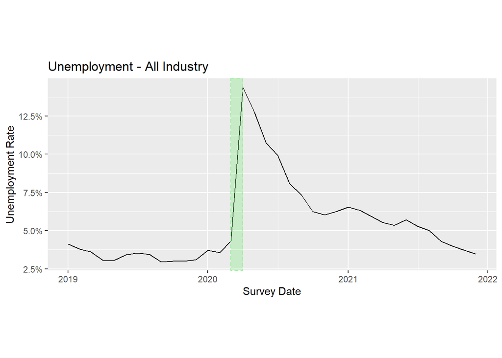

```r
## All industries unemployment rate over time
unemp_time <- demo_data %>%
  filter(indname != 'Military', indname != 'Other') %>%
  group_by(date_) %>%
  summarize(UnemploymentRate = 1- (weighted.mean(is_employed == TRUE, w = WTFINL))) %>%
  ggplot(aes(x = date_, y = UnemploymentRate)) + geom_line()+
  geom_rect(aes(xmin=as_date('2020-03-01'), xmax=as_date('2020-04-01'), ymin=-Inf, ymax=Inf),  linetype = 'dashed',color="light green", fill = 'light green' ,alpha=.01)+
  scale_y_continuous(labels = scales::percent_format(accuracy = .1))+
  labs(x = "Survey Date", y = "Unemployment Rate",
    title ="Unemployment - All Industry")+
  theme(aspect.ratio=3/7)
unemp_time
```

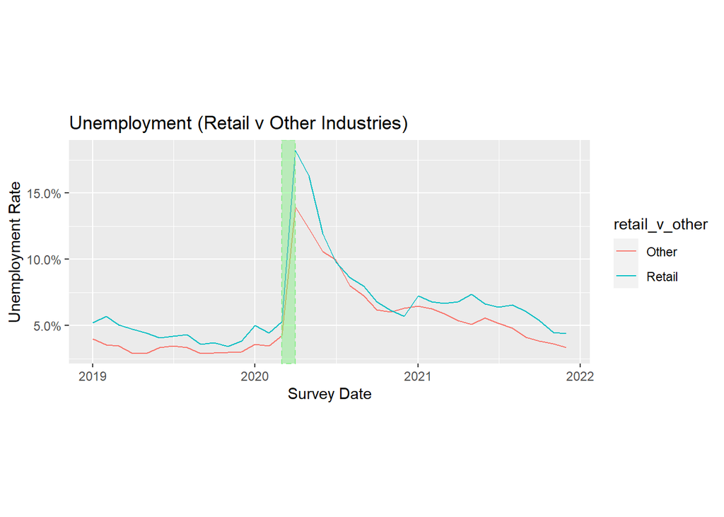

```r
## All industries v retail unemployment rate over time
unemp_retail_time <- demo_data %>%
  filter(indname != 'Military', indname != 'Other') %>%
  group_by(date_, retail_v_other) %>%
  summarize(UnemploymentRate = 1- (weighted.mean(is_employed == TRUE, w = WTFINL))) %>%
  ggplot(aes(x = date_, y = UnemploymentRate, color = retail_v_other)) + geom_line()+
  geom_rect(aes(xmin=as_date('2020-03-01'), xmax=as_date('2020-04-01'), ymin=-Inf, ymax=Inf),  linetype = 'dashed',color="light green", fill = 'light green' ,alpha=.01)+
  labs(x = "Survey Date", y = "Unemployment Rate",
    title ="Unemployment (Retail v Other Industries)")+
  scale_y_continuous(labels = scales::percent_format(accuracy = .1))+
  theme(aspect.ratio=3/7)
unemp_retail_time
```

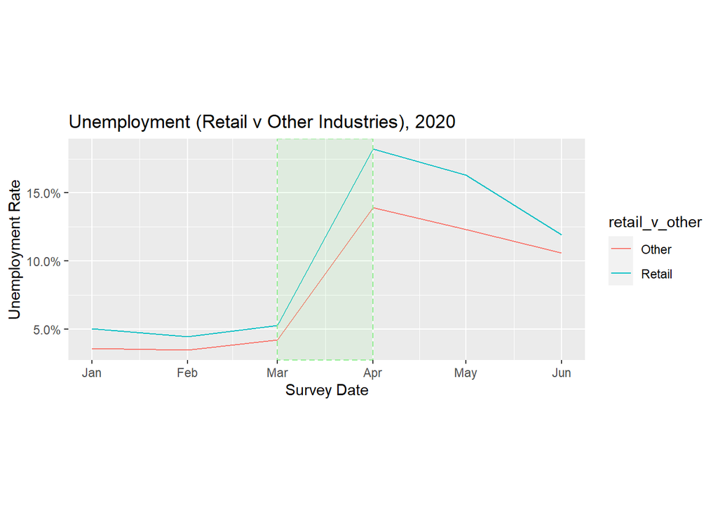

```r
## limit x window for clarity
unemp_time_skinny <- demo_data %>%
  filter(date_>=as_date('2020-01-01'),
         date_<= as_date('2020-06-01')) %>%
  filter(indname != 'Military', indname != 'Other') %>%
  group_by(date_, retail_v_other) %>%
  summarize(UnemploymentRate = 1- (weighted.mean(is_employed == TRUE, w = WTFINL))) %>%
  ggplot(aes(x = date_, y = UnemploymentRate, color = retail_v_other)) + geom_line()+
  geom_rect(aes(xmin=as_date('2020-03-01'), xmax=as_date('2020-04-01'), ymin=-Inf, ymax=Inf),  linetype = 'dashed',color="light green", fill = 'light green' ,alpha=.01)+
  labs(x = "Survey Date", y = "Unemployment Rate",
    title ="Unemployment (Retail v Other Industries), 2020")+
  scale_y_continuous(labels = scales::percent_format(accuracy = .1))+
  theme(aspect.ratio=3/7)
unemp_time_skinny
```

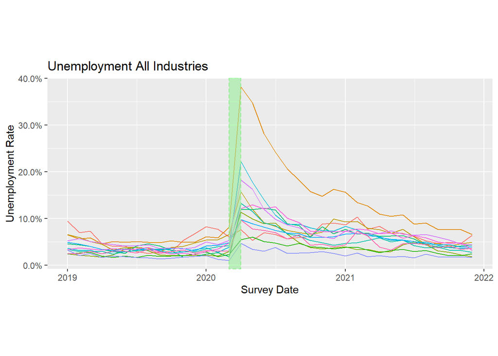

```r
unemp_industries <- demo_data %>%
  filter(indname != 'Military', indname != 'Other') %>%
  group_by(date_, indname) %>%
  summarize(UnemploymentRate = 1- (weighted.mean(is_employed == TRUE, w = WTFINL))) %>%
  ggplot(aes(x = date_, y = UnemploymentRate, color = indname)) + geom_line()+
  geom_rect(aes(xmin=as_date('2020-03-01'), xmax=as_date('2020-04-01'), ymin=-Inf, ymax=Inf),  linetype = 'dashed',color="light green", fill = 'light green' ,alpha=.01)+ labs(x = "Survey Date", y = "Unemployment Rate",
    title ="Unemployment All Industries")+
  scale_y_continuous(labels = scales::percent_format(accuracy = .1))+
  theme(aspect.ratio=3/7, legend.position = 'none')
unemp_industries
```

### 3.3.1 Geographical

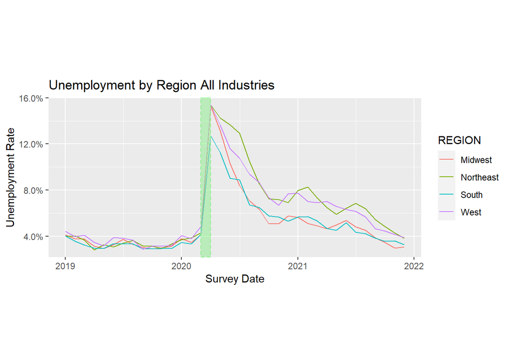

```r
unemp_by_region <- demo_data %>%
  filter(indname != 'Military', indname != 'Other') %>%
  group_by(date_, REGION) %>%
  summarize(UnemploymentRate = 1- (weighted.mean(is_employed == TRUE, w = WTFINL))) %>%
  ggplot(aes(x = date_, y = UnemploymentRate, color = REGION)) + geom_line()+
  geom_rect(aes(xmin=as_date('2020-03-01'), xmax=as_date('2020-04-01'), ymin=-Inf, ymax=Inf),  linetype = 'dashed',color="light green", fill = 'light green' ,alpha=.01)+
  labs(x = "Survey Date", y = "Unemployment Rate",
    title ="Unemployment by Region All Industries")+
  scale_y_continuous(labels = scales::percent_format(accuracy = .1))+
  theme(aspect.ratio=3/7)
unemp_by_region
```

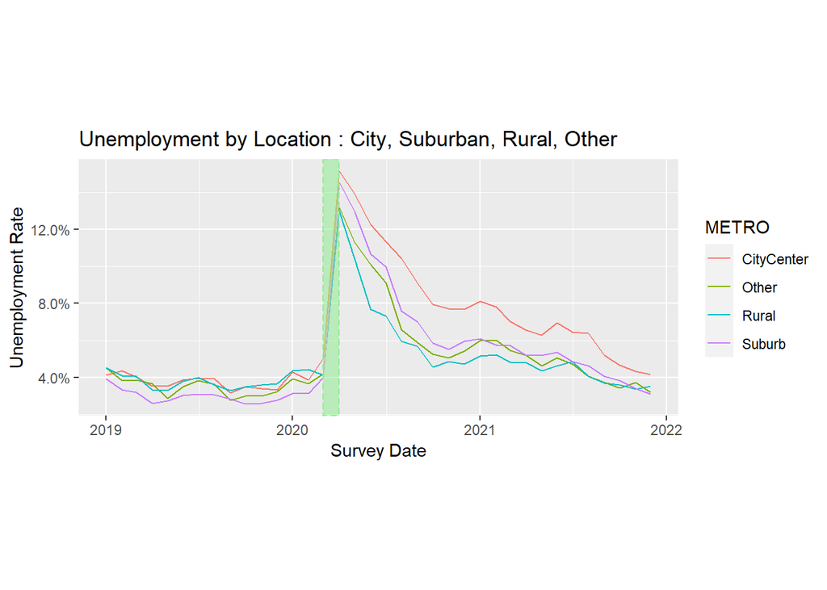

```r
unemp_by_metro <- demo_data %>%
  filter(indname != 'Military', indname != 'Other') %>%
  group_by(date_, METRO) %>%
  summarize(UnemploymentRate = 1- (weighted.mean(is_employed == TRUE, w = WTFINL))) %>%
  ggplot(aes(x = date_, y = UnemploymentRate, color = METRO)) + geom_line()+
  theme(aspect.ratio=3/7)+
  geom_rect(aes(xmin=as_date('2020-03-01'), xmax=as_date('2020-04-01'), ymin=-Inf, ymax=Inf),  linetype = 'dashed',color="light green", fill = 'light green' ,alpha=.01)+
  labs(x = "Survey Date", y = "Unemployment Rate",
    title ="Unemployment by Location : City, Suburban, Rural, Other")+
  scale_y_continuous(labels = scales::percent_format(accuracy = .1))+
  theme(aspect.ratio=3/7)
unemp_by_metro
```

### 3.3.2 Race

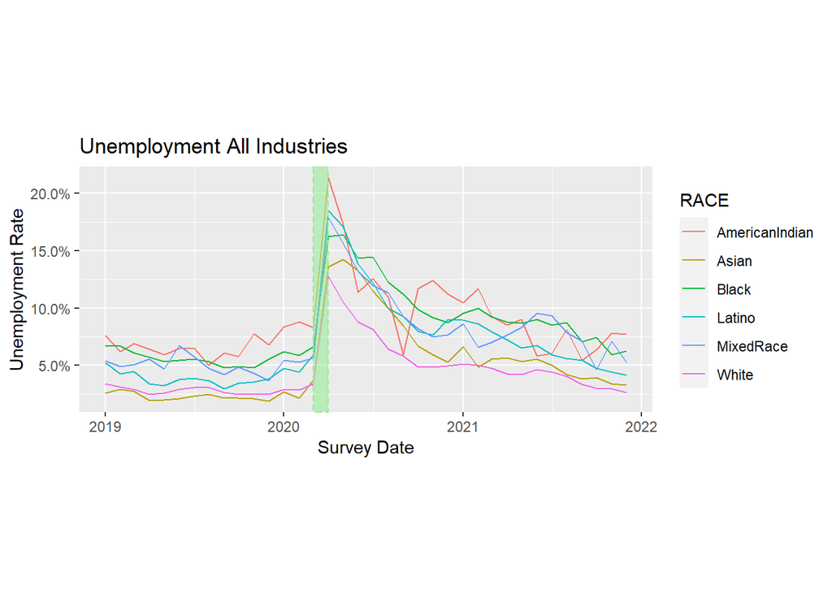

```r
#### RACE PRE-COVID EMPLOYMENT ####
unemp_by_race <- demo_data %>%
  filter(indname != 'Military', indname != 'Other') %>%
  group_by(date_, RACE) %>%
  summarize(UnemploymentRate = 1- (weighted.mean(is_employed == TRUE, w = WTFINL))) %>%
  ggplot(aes(x = date_, y = UnemploymentRate, color = RACE)) + geom_line()+
  theme(aspect.ratio=3/7)+
  geom_rect(aes(xmin=as_date('2020-03-01'), xmax=as_date('2020-04-01'), ymin=-Inf, ymax=Inf),  linetype = 'dashed',color="light green", fill = 'light green' ,alpha=.01)+
  labs(x = "Survey Date", y = "Unemployment Rate",
    title ="Unemployment All Industries")+
  scale_y_continuous(labels = scales::percent_format(accuracy = .1))+
  theme(aspect.ratio=3/7)
unemp_by_race
```

### 3.3.3 Age

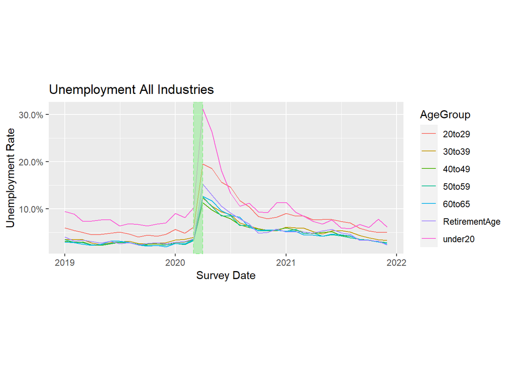

```r
unemp_by_age_group <- demo_data %>%
  filter(indname != 'Military', indname != 'Other') %>%
  group_by(date_, AgeGroup) %>%
  summarize(UnemploymentRate = 1- (weighted.mean(is_employed == TRUE, w = WTFINL))) %>%
  ggplot(aes(x = date_, y = UnemploymentRate, color = AgeGroup)) + geom_line()+
  theme(aspect.ratio=3/7)+
  geom_rect(aes(xmin=as_date('2020-03-01'), xmax=as_date('2020-04-01'), ymin=-Inf, ymax=Inf),  linetype = 'dashed',color="light green", fill = 'light green' ,alpha=.01)+
  labs(x = "Survey Date", y = "Unemployment Rate",
    title ="Unemployment All Industries")+
  scale_y_continuous(labels = scales::percent_format(accuracy = .1))+
  theme(aspect.ratio=3/7)
unemp_by_age_group
```

# 4 Regressions

```r
reg_df <- demo_data %>%
  select(period_type
         , date_
         ## Measure
         , is_employed
         , WTFINL
         ## Variables
         , IND, indname, REGION
         ## Fixed
         , AGE, sex, RACE, AgeGroup, MARST
  )

reg1 <- feols(is_employed~period_type + indname, se = 'hetero', data = reg_df)
reg1a <- feols(is_employed~period_type, se = 'hetero', data = reg_df)
etable(reg1, reg1a)
```

```
##                                                                                                         reg1
## Dependent Var.:                                                                                  is_employed
##
## (Intercept)                                                                               0.9655*** (0.0010)
## period_typeCovid                                                                         -0.0081*** (0.0009)
## period_typePost_Covid                                                                    -0.0292*** (0.0003)
## indnameArts,Entertainment,andRecreation,andAccommodationandFoodServices                  -0.0522*** (0.0012)
## indnameConstruction                                                                      -0.0095*** (0.0012)
## indnameEducationalServices,andHealthCareandSocialAssistance                               0.0159*** (0.0010)
## indnameFinanceandInsurance,andRealEstateandRentalandLeasing                               0.0237*** (0.0011)
## indnameInformation                                                                           0.0002 (0.0015)
## indnameManufacturing                                                                      0.0081*** (0.0011)
## indnameMilitary                                                                          -0.9502*** (0.0014)
## indnameOtherServices,ExceptPublicAdministration                                             -0.0010 (0.0012)
## indnameProfessional,Scientific,andManagement,andAdministrativeandWasteManagementServices   0.0032** (0.0011)
## indnamePublicAdministration                                                               0.0307*** (0.0011)
## indnameRetailTrade                                                                       -0.0066*** (0.0011)
## indnameTransportationandWarehousing,andUtilities                                            -0.0013 (0.0012)
## indnameWholesaleTrade                                                                     0.0136*** (0.0013)
## ________________________________________                                                 ___________________
## S.E. type                                                                                Heteroskedast.-rob.
## Observations                                                                                       1,951,872
## R2                                                                                                   0.01523
## Adj. R2                                                                                              0.01522
##
##                                                                                                        reg1a
## Dependent Var.:                                                                                  is_employed
##
## (Intercept)                                                                               0.9673*** (0.0002)
## period_typeCovid                                                                         -0.0077*** (0.0009)
## period_typePost_Covid                                                                    -0.0288*** (0.0003)
## indnameArts,Entertainment,andRecreation,andAccommodationandFoodServices
## indnameConstruction
## indnameEducationalServices,andHealthCareandSocialAssistance
## indnameFinanceandInsurance,andRealEstateandRentalandLeasing
## indnameInformation
## indnameManufacturing
## indnameMilitary
## indnameOtherServices,ExceptPublicAdministration
## indnameProfessional,Scientific,andManagement,andAdministrativeandWasteManagementServices
## indnamePublicAdministration
## indnameRetailTrade
## indnameTransportationandWarehousing,andUtilities
## indnameWholesaleTrade
## ________________________________________                                                 ___________________
## S.E. type                                                                                Heteroskedast.-rob.
## Observations                                                                                       1,951,872
## R2                                                                                                   0.00431
## Adj. R2                                                                                              0.00431
## ---
## Signif. codes: 0 '***' 0.001 '**' 0.01 '*' 0.05 '.' 0.1 ' ' 1
```

-controlling for industry and relative to agricultural industry, a one-unit change in pre-covid employment is associated with a 5.22% decrease in within the Entertainment and Recreation industry.

-controlling for industry and relative to agricultural industry, a one-unit change in pre-covid employment is associated with a 1.59% increase within the Educational Services industry.

-controlling for industry and relative to agricultural industry, a one-unit change in pre-covid employment is associated with a 2.37% increase within the Financial & Insurance services industry.

-controlling for industry and relative to agricultural industry, a one-unit change in pre-covid employment is associated with a .02% increase within the Information services industry.

-controlling for industry and relative to agricultural industry, a one-unit change in pre-covid employment is associated with a .81% increase within the Manufacturing industry.

-controlling for industry and relative to agricultural industry, a one-unit change in pre-covid employment is associated with a .1% decrease within Other Services Industry.

-controlling for industry and relative to agricultural industry, a one-unit change in pre-covid employment is associated with a .32% increase within Professional, Scientific and Management Industry.

-controlling for industry and relative to agricultural industry, a one-unit change in pre-covid employment is associated with a .66% decrease within Retail Trade Industry.

-controlling for industry and relative to agricultural industry, a one-unit change in pre-covid employment is associated with a .13% decrease within Transportation & warehousing Industry.

-controlling for industry and relative to agricultural industry, a one-unit change in pre-covid employment is associated with a 1.36% increase within Wholesale Trade Industry.

```r
reg2 <- feols(is_employed~indname + period_type, se = 'hetero', data = reg_df)
etable(reg2)
```

```
##                                                                                                         reg2
## Dependent Var.:                                                                                  is_employed
##
## (Intercept)                                                                               0.9655*** (0.0010)
## indnameArts,Entertainment,andRecreation,andAccommodationandFoodServices                  -0.0522*** (0.0012)
## indnameConstruction                                                                      -0.0095*** (0.0012)
## indnameEducationalServices,andHealthCareandSocialAssistance                               0.0159*** (0.0010)
## indnameFinanceandInsurance,andRealEstateandRentalandLeasing                               0.0237*** (0.0011)
## indnameInformation                                                                           0.0002 (0.0015)
## indnameManufacturing                                                                      0.0081*** (0.0011)
## indnameMilitary                                                                          -0.9502*** (0.0014)
## indnameOtherServices,ExceptPublicAdministration                                             -0.0010 (0.0012)
## indnameProfessional,Scientific,andManagement,andAdministrativeandWasteManagementServices   0.0032** (0.0011)
## indnamePublicAdministration                                                               0.0307*** (0.0011)
## indnameRetailTrade                                                                       -0.0066*** (0.0011)
## indnameTransportationandWarehousing,andUtilities                                            -0.0013 (0.0012)
## indnameWholesaleTrade                                                                     0.0136*** (0.0013)
## period_typeCovid                                                                         -0.0081*** (0.0009)
## period_typePost_Covid                                                                    -0.0292*** (0.0003)
## ________________________________________                                                 ___________________
## S.E. type                                                                                Heteroskedast.-rob.
## Observations                                                                                       1,951,872
## R2                                                                                                   0.01523
## Adj. R2                                                                                              0.01522
## ---
## Signif. codes: 0 '***' 0.001 '**' 0.01 '*' 0.05 '.' 0.1 ' ' 1
```

Interpretation reg2- note:summary table above in findings. -controlling for period_tyep[pre-covid(1/2019-2/2020), covid(3/2020), and post covid(4/2020-12/2021)] and relative to agricultural industry, a one-unit change in industry employment is associated with a -5.22% decrease within the Entertainment and Recreation industry.

-controlling for period_tyep[pre-covid(1/2019-2/2020), covid(3/2020), and post covid(4/2020-12/2021)] and relative to agricultural industry, a one-unit change in industry employment is associated with a -.66% decrease within the Retail Trade industry.

-controlling for period_tyep[pre-covid(1/2019-2/2020), covid(3/2020), and post covid(4/2020-12/2021)] and relative to agricultural industry, a one-unit change in industry employment is associated with a -.13% decrease within the Transportation & warehousing industry.